# PCIT-CoS-Waitlist RCT Paper 1: CCQ Parenting Self-Efficacy, Controlling for ASD

Nancy Briggs

05 JAN 2021

### CCQ Parenting Self-Efficacy Adjusting for ASD

#### Descriptives

| asdcase | group | time | n | mean | sd | median | min | max |
| --- | --- | --- | --- | --- | --- | --- | --- | --- |
| 0 | 1 | 1 | 24 | 8.132 | 1.043 | 8.250 | 6.000 | 9.750 |
| 0 | 1 | 2 | 18 | 8.736 | 0.963 | 8.708 | 6.083 | 10.000 |
| 0 | 1 | 3 | 13 | 8.532 | 0.772 | 8.750 | 6.833 | 9.833 |
| 0 | 2 | 1 | 25 | 7.999 | 1.138 | 8.333 | 4.500 | 9.250 |
| 0 | 2 | 2 | 11 | 8.121 | 1.134 | 8.167 | 5.417 | 9.667 |
| 0 | 2 | 3 | 5 | 8.500 | 0.580 | 8.167 | 8.000 | 9.250 |
| 0 | 3 | 1 | 22 | 8.306 | 1.021 | 8.333 | 6.417 | 9.833 |
| 0 | 3 | 2 | 20 | 8.267 | 0.803 | 8.292 | 7.250 | 9.833 |
| 0 | 3 | 3 | 0 | NaN | NA | NA | Inf | -Inf |
| 1 | 1 | 1 | 6 | 7.486 | 1.670 | 7.833 | 5.167 | 9.833 |
| 1 | 1 | 2 | 5 | 8.417 | 1.500 | 8.667 | 6.583 | 9.833 |
| 1 | 1 | 3 | 5 | 7.367 | 1.873 | 8.000 | 4.250 | 8.833 |
| 1 | 2 | 1 | 3 | 8.500 | 0.750 | 8.500 | 7.750 | 9.250 |
| 1 | 2 | 2 | 2 | 7.708 | 0.177 | 7.708 | 7.583 | 7.833 |
| 1 | 2 | 3 | 0 | NaN | NA | NA | Inf | -Inf |
| 1 | 3 | 1 | 4 | 8.701 | 1.214 | 8.777 | 7.417 | 9.833 |
| 1 | 3 | 2 | 2 | 8.542 | 1.709 | 8.542 | 7.333 | 9.750 |
| 1 | 3 | 3 | 0 | NaN | NA | NA | Inf | -Inf |

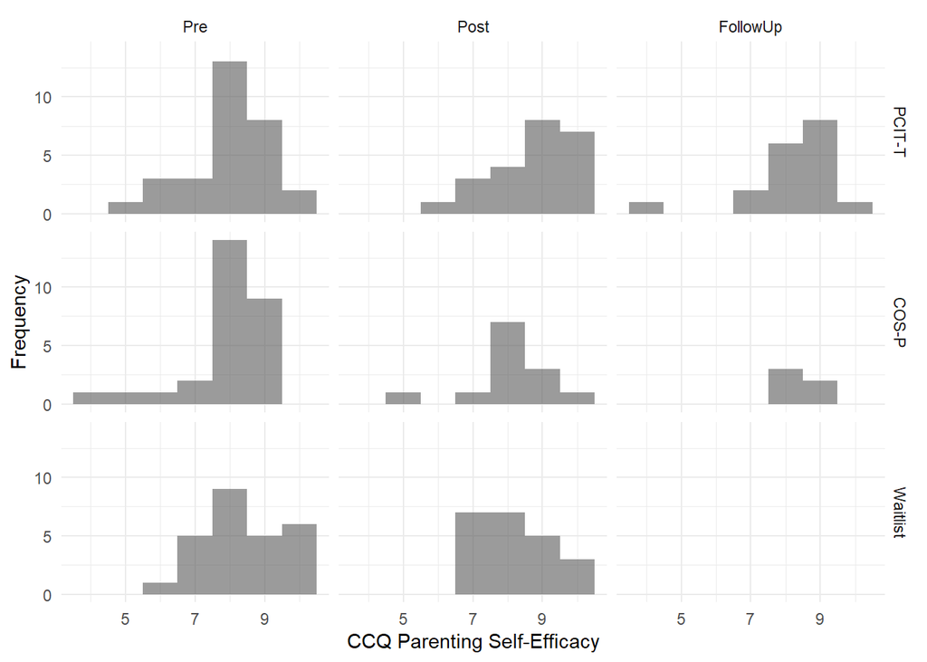

#### Model & Results

A linear mixed model with random effect for individual and fixed effects of group, time and the interaction was run. ASD status was then entered into the model as a main effect and then the 3-way interaction. Estimated marginal means were obtained, and contrasts specified to test Hypothesis 1 and Hypothesis 2.

```
## fixed-effect model matrix is rank deficient so dropping 1 column / coefficient
```

```
## fixed-effect model matrix is rank deficient so dropping 3 columns / coefficients
```

```
## refitting model(s) with ML (instead of REML)
```

|  | Effect | npar | AIC | BIC | logLik | deviance | Chisq | Df | Pr(>Chisq) |
| --- | --- | --- | --- | --- | --- | --- | --- | --- | --- |
| result0 | Intercept | 3 | 480.872 | 490.190 | -237.436 | 474.872 | NA | NA | NA |
| result0_5 | ASD | 4 | 482.486 | 494.909 | -237.243 | 474.486 | 0.387 | 1 | 0.534 |
| result1 | Group* Time*ASD | 6 | 485.149 | 503.785 | -236.575 | 473.149 | 1.336 | 2 | 0.513 |
| result2 | ASD + Group + Time | 8 | 485.709 | 510.557 | -234.855 | 469.709 | 3.440 | 2 | 0.179 |
| result3 | ASD + Group + Time + Group*Time | 11 | 486.224 | 520.389 | -232.112 | 464.224 | 5.486 | 3 | 0.140 |
| result4 | Group* Time*ASD | 17 | 490.434 | 543.235 | -228.217 | 456.434 | 7.790 | 6 | 0.254 |

There is no evidence that ASD moderates the 2-way group*time interaction (the 3-way interaction p=0.254).

Model3, the model with Group*Time, adjusted by ASD will be the model I use for Estimated Means.

```r
summary(result3)
```

```
## Linear mixed model fit by REML. t-tests use Satterthwaite's method [
## lmerModLmerTest]
## Formula: outcome ~ asdcase + group * time + (1 | id)
##    Data: dat
##
## REML criterion at convergence: 473.8
##
## Scaled residuals:
##     Min      1Q  Median      3Q     Max
## -3.7715 -0.3576  0.0903  0.4925  1.9044
##
## Random effects:
##  Groups   Name        Variance Std.Dev.
##  id       (Intercept) 0.5143   0.7171
##  Residual             0.6481   0.8051
## Number of obs: 165, groups:  id, 85
##
## Fixed effects:
##               Estimate Std. Error        df t value Pr(>|t|)
## (Intercept)    8.04143    0.20483 123.22803  39.259  < 2e-16 ***
## asdcase1      -0.19328    0.28319  75.89572  -0.682  0.49700
## group2         0.03176    0.28452 126.97880   0.112  0.91128
## group3         0.35762    0.28865 128.69770   1.239  0.21762
## time2          0.66098    0.22922  85.38096   2.884  0.00497 **
## time3          0.35124    0.25071  88.16680   1.401  0.16473
## group2:time2  -0.62468    0.37065  94.45445  -1.685  0.09522 .
## group3:time2  -0.68838    0.33194  85.72791  -2.074  0.04110 *
## group2:time3  -0.05755    0.50216  98.70524  -0.115  0.90899
## ---
## Signif. codes:  0 '***' 0.001 '**' 0.01 '*' 0.05 '.' 0.1 ' ' 1
##
## Correlation of Fixed Effects:
##             (Intr) asdcs1 group2 group3 time2  time3  grp2:2 grp3:2
## asdcase1    -0.277
## group2      -0.690  0.092
## group3      -0.668  0.047  0.476
## time2       -0.457 -0.010  0.330  0.326
## time3       -0.411 -0.035  0.300  0.297  0.415
## group2:tim2  0.288 -0.014 -0.426 -0.203 -0.618 -0.256
## group3:tim2  0.307  0.037 -0.225 -0.490 -0.691 -0.288  0.426
## group2:tim3  0.200  0.036 -0.310 -0.147 -0.207 -0.500  0.315  0.144
## fit warnings:
## fixed-effect model matrix is rank deficient so dropping 1 column / coefficient
```

#### Estimated Means & Change

Estimated means for each Treatment and Time (adjusted by ASD status) are presented. In addition, within-group change between time points is presented with 95% CIs.

##### Group mean difference at each timepoint

Effect sizes all calculated by the pooled T1 SD of the outcome. Adjusted p-value from Bonferroni correction.

Group Differences at Each Time Point

| Group Difference | Time | Mean | SE | t | p | adj p | Lower CL | Upper CL | Effect Size | Lower CL | Upper CL |
| --- | --- | --- | --- | --- | --- | --- | --- | --- | --- | --- | --- |
| 1 - 2 | 1 | -0.032 | 0.285 | -0.112 | 0.993 | 1.000 | -0.707 | 0.643 | -0.028 | -0.588 | 0.490 |
| 1 - 3 | 1 | -0.358 | 0.289 | -1.239 | 0.433 | 0.653 | -1.042 | 0.327 | -0.311 | -0.931 | 0.172 |
| 2 - 3 | 1 | -0.326 | 0.293 | -1.111 | 0.509 | 0.806 | -1.022 | 0.370 | -0.284 | -0.841 | 0.290 |
| 1 - 2 | 2 | 0.593 | 0.360 | 1.647 | 0.229 | 0.305 | -0.259 | 1.445 | 0.516 | -0.054 | 1.296 |
| 1 - 3 | 2 | 0.331 | 0.316 | 1.046 | 0.549 | 0.892 | -0.418 | 1.080 | 0.288 | -0.302 | 0.901 |
| 2 - 3 | 2 | -0.262 | 0.363 | -0.722 | 0.751 | 1.000 | -1.122 | 0.598 | -0.228 | -0.970 | 0.379 |
| 1 - 2 | 3 | 0.026 | 0.497 | 0.052 | 0.999 | 1.000 | -1.152 | 1.204 | 0.022 | -0.824 | 0.889 |
| 1 - 3 | 3 | NA | NA | NA | NA | NA | NA | NA | NA | NA | NA |
| 2 - 3 | 3 | NA | NA | NA | NA | NA | NA | NA | NA | NA | NA |

* Effect size scaled by pooled T1 SD  
† ES 95% Bootstrapped Percentile CI limits  
‡ If you want a positive ES (and it is calculated as negative), be sure to switch the signs and positions of the lower and upper CIs.

##### Change within each group

Within-Group Change and Effect Sizes

| Change | Group | Mean | SE | t | p | adj p | Lower CL | Upper CL | Effect Size | Lower CL | Upper CL |
| --- | --- | --- | --- | --- | --- | --- | --- | --- | --- | --- | --- |
| 1 - 2 | 1 | -0.661 | 0.230 | -2.878 | 0.014 | 0.015 | -1.209 | -0.113 | -0.575 | -1.058 | -0.239 |
| 1 - 3 | 1 | -0.351 | 0.251 | -1.397 | 0.347 | 0.498 | -0.951 | 0.248 | -0.306 | -0.784 | 0.060 |
| 2 - 3 | 1 | 0.310 | 0.261 | 1.189 | 0.463 | 0.714 | -0.312 | 0.932 | 0.270 | -0.197 | 0.763 |
| 1 - 2 | 2 | -0.036 | 0.293 | -0.124 | 0.992 | 1.000 | -0.733 | 0.660 | -0.032 | -0.522 | 0.527 |
| 1 - 3 | 2 | -0.294 | 0.438 | -0.671 | 0.781 | 1.000 | -1.335 | 0.747 | -0.256 | -1.057 | 0.464 |
| 2 - 3 | 2 | -0.257 | 0.454 | -0.567 | 0.838 | 1.000 | -1.339 | 0.824 | -0.224 | -1.123 | 0.537 |
| 1 - 2 | 3 | 0.027 | 0.240 | 0.114 | 0.993 | 1.000 | -0.546 | 0.601 | 0.024 | -0.430 | 0.486 |
| 1 - 3 | 3 | NA | NA | NA | NA | NA | NA | NA | NA | NA | NA |
| 2 - 3 | 3 | NA | NA | NA | NA | NA | NA | NA | NA | NA | NA |

* Effect size scaled by pooled T1 SD  
† ES 95% Bootstrapped Percentile CI limits  
‡ If you want a positive ES (and it is calculated as negative), be sure to switch the signs and positions of the lower and upper CIs.

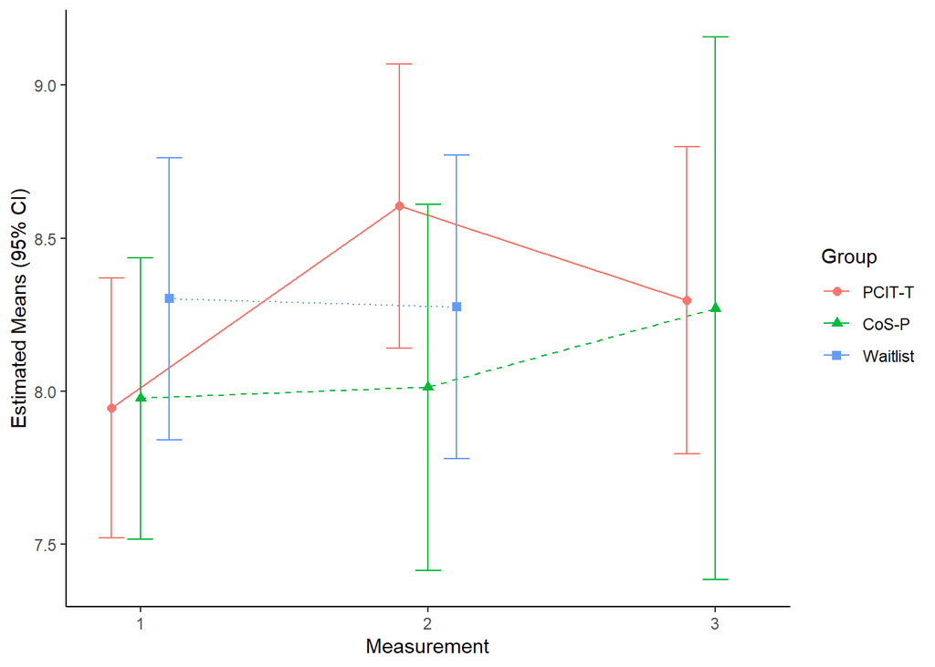

#### Hypothesis 1

We hypothesize that from baseline (‘T1’) to post-treatment/waitlist (‘T2’) there will be a gradient effect, whereby parent-child dyads who receive PCIT-T will show the greatest gains and parent-child dyads who receive no treatment will show the least gains. For the outcome, then, the null hypothesis is:

$H_0: \text {mean change}(\text{PCIT-T}) = \text {mean change}(\text{CoS-P}) = \text {mean change}(\text{Waitlist})$ $H_A: \text {mean change}(\text{PCIT-T}) > \text {mean change}(\text{CoS-P}) > \text {mean change}(\text{Waitlist})$

This is a joint hypothesis test.

First, confirming that the ordering of the means is as hypothesized:

```
## group = 1:
##  contrast estimate    SE    df t.ratio p.value
##  1 - 2     -0.6610 0.230  85.0  -2.878  0.0139
##  1 - 3     -0.3512 0.251  87.8  -1.397  0.3468
##  2 - 3      0.3097 0.261  82.8   1.189  0.4633
##
## group = 2:
##  contrast estimate    SE    df t.ratio p.value
##  1 - 2     -0.0363 0.293 100.0  -0.124  0.9916
##  1 - 3     -0.2937 0.438 102.3  -0.671  0.7809
##  2 - 3     -0.2574 0.454  90.1  -0.567  0.8378
##
## group = 3:
##  contrast estimate    SE    df t.ratio p.value
##  1 - 2      0.0274 0.240  85.8   0.114  0.9929
##  1 - 3      nonEst    NA    NA      NA      NA
##  2 - 3      nonEst    NA    NA      NA      NA
##
## Results are averaged over the levels of: asdcase
## Degrees-of-freedom method: kenward-roger
## P value adjustment: tukey method for comparing a family of 3 estimates
```

So, the mean change for PCITT > COSP > Waitlist.

Now, to get the p-value associated with the joint hypothesis.

```
##   (Intercept) asdcase1 group2 group3 time2 time3 group2:time2 group3:time2
## 1           0        0      0      0     0     0           -1            0
## 2           0        0      0      0     0     1            0            1
##   group2:time3
## 1            0
## 2            0
```

```
##
##   General Linear Hypotheses
##
## Linear Hypotheses:
##        Estimate
## 1 == 0   0.6247
## 2 == 0  -0.3371
##
## Global Test:
##     F DF1 DF2 Pr(>F)
## 1 1.6   2 154 0.2053
```

p>0.05, so this joint null hypothesis is not rejected.

#### Hypothesis 2

There will be a gradient of size of change from T2 to T3 such that the change in the PCIT-T group > the change in the CoS-P group. This isn’t really a gradient; it’s just 1 hypothesis.

First, the change in PCITT and COSP from time 2 to time 3:

```
## group = 1:
##  contrast estimate    SE    df t.ratio p.value
##  1 - 2     -0.6610 0.230  85.0  -2.878  0.0139
##  1 - 3     -0.3512 0.251  87.8  -1.397  0.3468
##  2 - 3      0.3097 0.261  82.8   1.189  0.4633
##
## group = 2:
##  contrast estimate    SE    df t.ratio p.value
##  1 - 2     -0.0363 0.293 100.0  -0.124  0.9916
##  1 - 3     -0.2937 0.438 102.3  -0.671  0.7809
##  2 - 3     -0.2574 0.454  90.1  -0.567  0.8378
##
## group = 3:
##  contrast estimate    SE    df t.ratio p.value
##  1 - 2      0.0274 0.240  85.8   0.114  0.9929
##  1 - 3      nonEst    NA    NA      NA      NA
##  2 - 3      nonEst    NA    NA      NA      NA
##
## Results are averaged over the levels of: asdcase
## Degrees-of-freedom method: kenward-roger
## P value adjustment: tukey method for comparing a family of 3 estimates
```

```
##
##   Simultaneous Tests for General Linear Hypotheses
##
## Fit: lmer(formula = outcome ~ asdcase + group * time + (1 | id), data = dat)
##
## Linear Hypotheses:
##        Estimate Std. Error z value Pr(>|z|)
## 1 == 0   0.5671     0.5217   1.087    0.277
## (Adjusted p values reported -- single-step method)
```

p>0.05.

#### Residuals

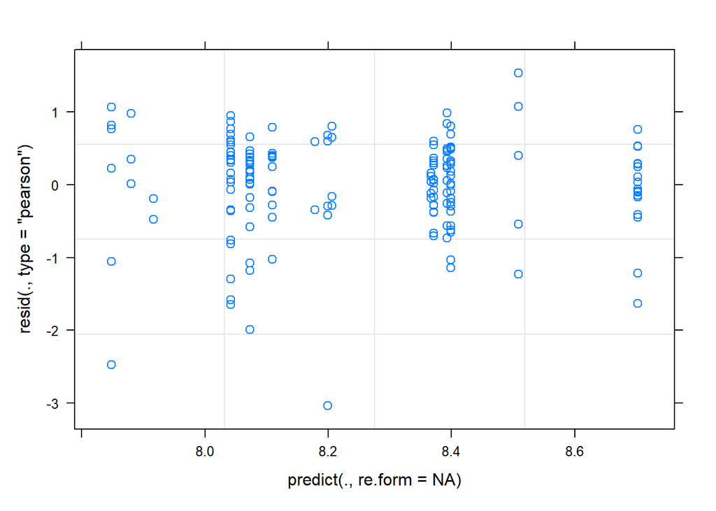

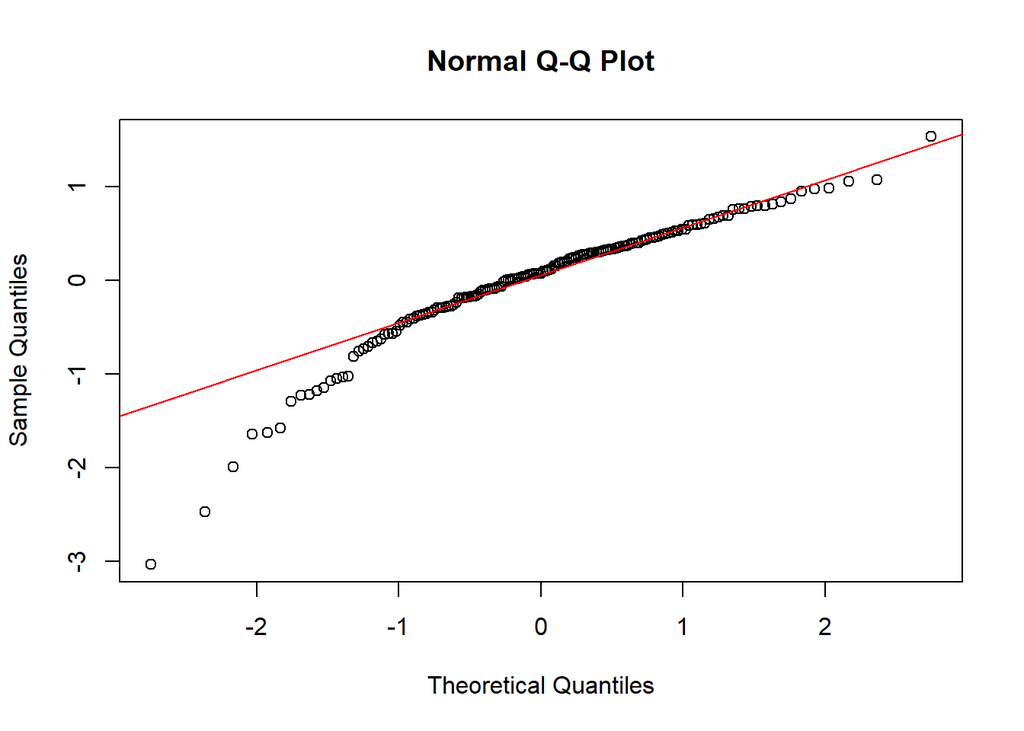

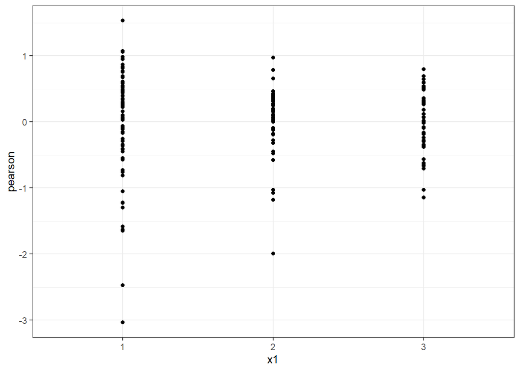

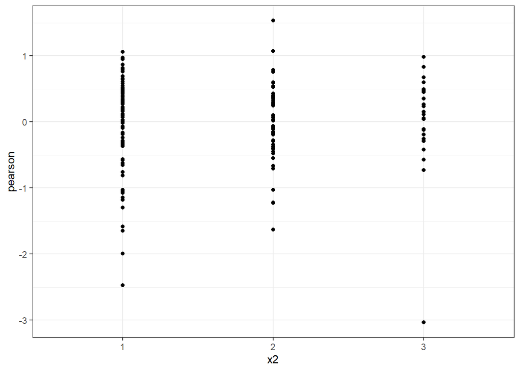

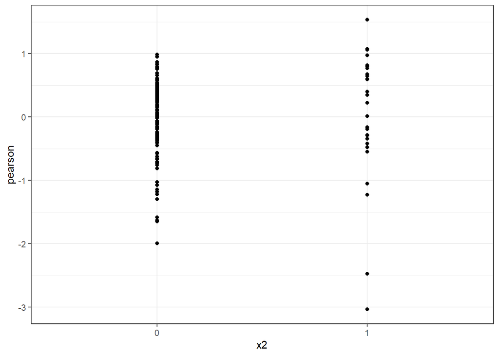

```r
rm(list = ls())
```